# Differential Expression Analysis

## Introduction

This exercise will use RNA Seq data (gene counts) from cultures of *Saccharomyces cerevisiae* of mating type **a** that have been externally treated with a pheromone called **‘alpha factor’**. In the wild, haploid yeast cells mate via the production of pheromones (Figure 1), which signals their presence to neighboring cells. When cells of the opposite mating type sense each other (via their pheromones) they respond by forming ‘shmoos’, growth projections that allow cells to make contact and subsequently mate to form a diploid cell. The aim of this work was therefore to find out how pheromone treatment affects cells, from a genome-wide perspective.

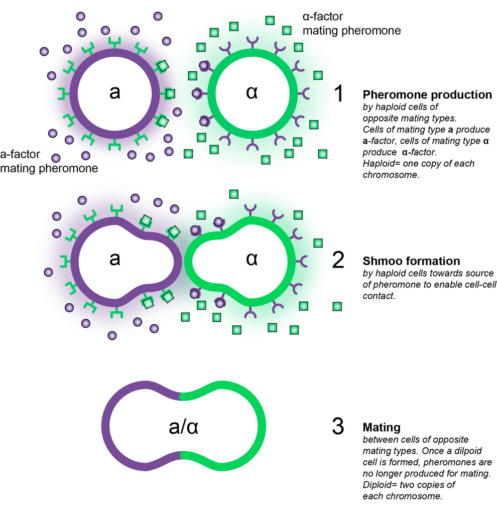

**Figure 1** Adapted from Wikipedia

## R session setup

Data is here is classified as either pheromone-affected or pheromone-unaffected. The count data files are located in the **data/gene_counts/** subdirectory in the **‘RNAseq1_DEanalysis’** directory.

The gene_counts_glucose.txt dataset corresponds to glucose as the carbon source, whereas the gene_counts_ethanol.txt dataset used ethanol. This was to show the effect of pheromone on cells undergoing two different types of metabolism: fermentation (with glucose) or respiration (with ethanol). Each dataset includes 6 pheromone-affected samples, and several pheromone-unaffected samples (24 for glucose, 15 for ethanol).

1. Start R and use setwd() (or Session > Set Working Directory > Choose Directory… from the top menu bar) to change the working directory to the RNAseq1_DEanalysis/ directory, which should contain a subdirectory named data/.
2. We will use the following R packages in this exercise:

```r
# Load R-packages required for analysis
# First time: need to install the packages. Once installed, you don't need to repeat these commands above (you can comment them out with a #-sign in front).

# After installing the software the first time, load the R-packages that we need. This you need to do every time you start a new R session.
library(limma)
library(edgeR)
library(tidyverse)
library(RColorBrewer)
#If you are unable to load the package, try to install it using the following commands:
# if (!require("BiocManager", quitely = TRUE))
#  install.packages("BiocManager", dependencies = TRUE)
# BiocManager::install(c("edgeR"), update = TRUE, ask = FALSE)
```

## Load data

3. Begin by loading the count data corresponding to the experiment of interest (glucose or ethanol conditions):

```r
count.data <- read.delim('data/gene_counts/gene_counts_glucose.txt', stringsAsFactors=F, row.names=1)
# count.data <- read.delim('data/gene_counts/gene_counts_ethanol.txt', stringsAsFactors=F, row.names=1)

# preview the first few rows of the data
head(count.data)
```

```
##           P1  P2  P3  P4  P5  P6  U1  U2  U3 U4  U5  U6 U7 U8 U9 U10 U11 U12
## 15S_rRNA   7  10  14  16  45   7 127   9   0  6   1   3 11  9 36   6   5   3
## 21S_rRNA  17  36  37  54 110  32 291  19  13 15  33   8 14 21 61  10  14   6
## HRA1       0   1   2   0   1   3   6   1   5  6   4   6  2  3  1   4   2   1
## ICR1      90  58  81  56  62  75  68  60  68 64  85  61 53 61 59  65  60  69
## LSR1     194 187 252 273 314 363 209 104 118 83 104 109 51 48 59  31  47  34
## NME1      35  22  27  13  14  15   9   8   9 14   6  23 11 12 16   8   6   7
##          U13 U14 U15 U16 U17 U18 U19 U20 U21 U22 U23 U24
## 15S_rRNA   5   5   3   9   9  58  11   4   1   1   2   8
## 21S_rRNA  14   7   7  28  33 113  29   5   9  12   7  18
## HRA1       3   6   1   1   2   2   4   1   3   2   3   4
## ICR1      61  64  63  78  39  62 107  88 100 100  92 100
## LSR1      59  37  39  55  38  78  67  58  49  61  76  61
## NME1      13   8  11  26   9  19  13  15  11  14  13  12
```

```r
# View(count.data)    #you may have a look at the count data in Rstudio
```

> **Question 1**: How many genes are in the dataset?

> **Answers:**

## Differential expression analysis

We will perform a differential expression (DE) analysis using the [edgeR](https://bioconductor.org/packages/release/bioc/html/edgeR.html). This exercise uses/explains only a little of edgeR, so it is strongly encouraged that you take a look at the [edgeR User’s Guide](https://bioconductor.org/packages/release/bioc/vignettes/edgeR/inst/doc/edgeRUsersGuide.pdf). Another package that is commonly used for DE analysis is [DESeq2](https://bioconductor.org/packages/release/bioc/html/DESeq2.html), which also has a very nice [User’s Guide](https://bioconductor.org/packages/release/bioc/vignettes/DESeq2/inst/doc/DESeq2.html). Although DESeq2 will not be covered in this exercise, we encourage you to check it out sometime.

### Data setup and exploration

We want to determine which genes are differentially expressed between two groups of samples - in this case, between “pheromone-unaffected” and “pheromone-affected” samples, which we have indicated by column names beginning with a “U” or “P”, respectively. We can take a quick look at the column names to see what samples we have:

```r
colnames(count.data)
```

```
##  [1] "P1"  "P2"  "P3"  "P4"  "P5"  "P6"  "U1"  "U2"  "U3"  "U4"  "U5"  "U6"
## [13] "U7"  "U8"  "U9"  "U10" "U11" "U12" "U13" "U14" "U15" "U16" "U17" "U18"
## [25] "U19" "U20" "U21" "U22" "U23" "U24"
```

4. Generate a factor specifying the group to which each sample belongs:

```r
sample.groups <- factor(startsWith(colnames(count.data), 'P'), labels=c('unaffected','pheromone'))
#check that we set up the groups correctly
data.frame(sample=colnames(count.data), groups=sample.groups)
```

```
##    sample     groups
## 1      P1  pheromone
## 2      P2  pheromone
## 3      P3  pheromone
## 4      P4  pheromone
## 5      P5  pheromone
## 6      P6  pheromone
## 7      U1 unaffected
## 8      U2 unaffected
## 9      U3 unaffected
## 10     U4 unaffected
## 11     U5 unaffected
## 12     U6 unaffected
## 13     U7 unaffected
## 14     U8 unaffected
```

[output cut: 16 more lines]

5. Create a DGEList object from the count.data dataframe and sample.groups factor:

```r
y <- DGEList(counts=count.data, group=sample.groups)
```

This DGEList object ‘holds’ the dataset to be analysed by edgeR and the subsequent calculations relevant for the analysis.

Before performing any DE analysis, we can take a look at similarities and differences among different samples using a multidimensional scaling (MDS) plot:

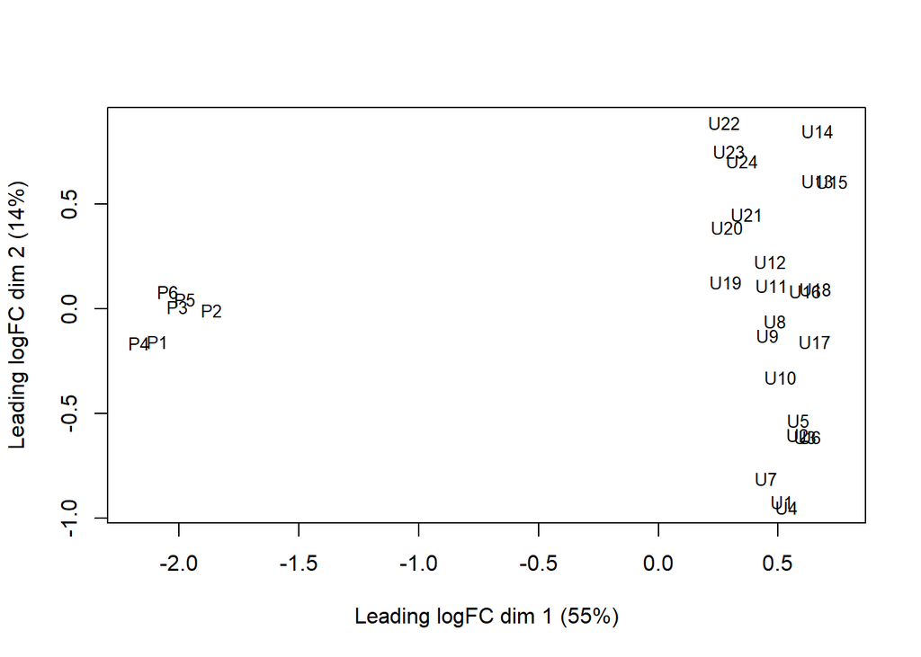

```r
plotMDS(y, cex=0.8) #"ces" sets the label font size
```

> **Question 2**: What is MDS, and how does it compare/contrast with related techniques, such as principal component analysis (PCA)?

> **Answer:**

> **Question 3**: Does it look like our samples are grouping/separating well based on their pheromone status? Do you notice any other patterns in the data?

> **Answer:**

### Filtering and normalization

Often, RNA Seq data will contain low-count genes that are not expressed, or expressed at very low levels in many samples. The data for these genes is essentially noise that does not provide any meaningful information and should therefore be removed prior to DE analysis.

Although there is no single “correct” approach for removing low-count genes, a common technique involves removing those that are below some threshold in a given fraction of the samples.

6. Filter (remove) low-count genes from the count data, using an arbitrary cut off of 10 reads:

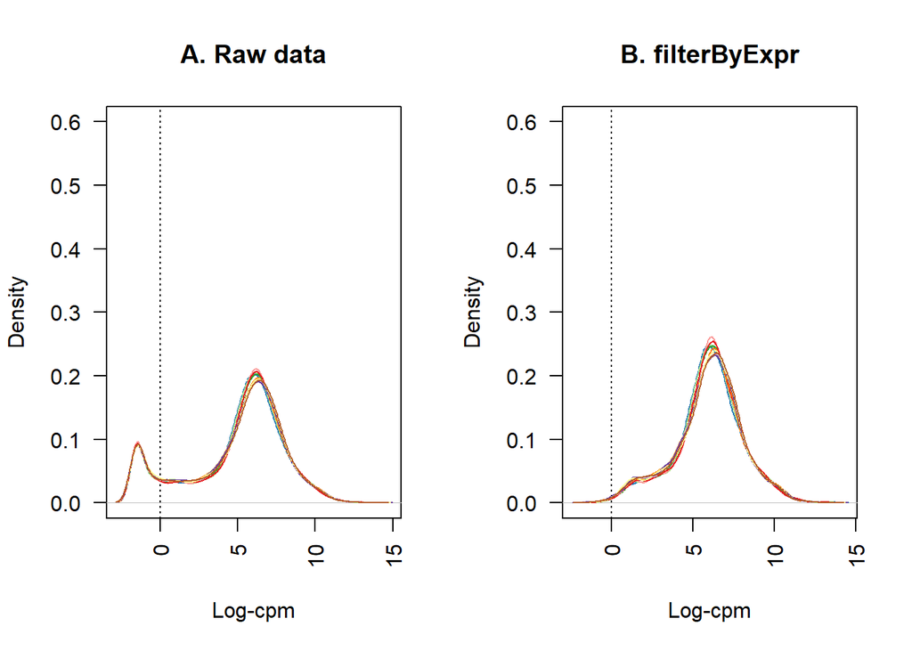

```r
#Normalize for library size, by taking the log count-per-million. It's not a satisfactory normalization, but we just use it to plot raw reads
cpm <- cpm(y)
lcpm <- cpm(y, log = T)

#Plot raw logCPM reads before filtering
nsamples <- ncol(y)
col <- brewer.pal(nsamples, "Paired") # Ignore warning, some samples will have identical color.
par(mfrow = c(1, 2))
plot(
    density(lcpm[, 1]),
    col = col[1],
    ylim = c(0, 0.6),
    las = 2,
    main = "A. Raw data",
    xlab = "Log-cpm")
abline(v = 0, lty = 3)
for (i in 2:nsamples) {
  den <- density(lcpm[, i])
  lines(den$x, den$y, col = col[i])
}


#Filter with filterByExpr function
keep <- filterByExpr(y, min.count = 10)
y_Filtered <- y[keep, keep.lib.sizes=F]

#Plot new logCPM reads after filtering
lcpm <- cpm(y_Filtered, log = T)

plot(density(lcpm[, 1]),
     col = col[1],
     ylim = c(0, 0.6),
     las = 2,
     main = "B. filterByExpr",
     xlab = "Log-cpm")
abline(v = 0, lty = 3)
for (i in 2:nsamples) {
  den <- density(lcpm[, i])
  lines(den$x, den$y, col = col[i])
}
```

The **filterByExpr** function will only keep genes that have at least **min.count** counts per million (CPM) in at least **n** samples, where **n** is the number of samples in the smallest group (the **pheromone** group, in this case, where **n = 6**).

The **keep.lib.sizes=F** argument specifies that we want to recalculate the sample library sizes after removing the low-count genes from the data.

The next step is to normalize the data by RNA composition, in order to address problems caused by the counts in a sample being dominated by only a few highly expressed genes. This can cause other genes in the sample to exhibit artificially low count values. The normalization factors calculated using the **calcNormFactors** function are then used to scale the counts to avoid such problems.

7. Calculate the normalization factors for each sample:

```r
#Calculate the normalization factors for each sample
y_TMM <- calcNormFactors(y_Filtered)

#To view the normalization factors calculated for each sample (as well as library sizes), we can take a look at the samples attribute of our DGEList, y:
y_TMM$samples
```

```
##          group lib.size norm.factors
## P1   pheromone  6020320    0.9361156
## P2   pheromone  6092399    0.9227982
## P3   pheromone  6376118    0.9373895
## P4   pheromone  5644928    0.9520398
## P5   pheromone  5916957    0.9523094
## P6   pheromone  5796230    0.9594617
## U1  unaffected  5479443    0.9919637
## U2  unaffected  5173270    0.9813800
## U3  unaffected  6286461    1.0008894
## U4  unaffected  6138251    0.9937387
## U5  unaffected  6720912    1.0093275
## U6  unaffected  6992254    1.0213692
## U7  unaffected  5174199    1.0116285
## U8  unaffected  5369132    1.0287401
## U9  unaffected  5061261    1.0170105
## U10 unaffected  5503517    1.0073924
## U11 unaffected  5455659    1.0401376
## U12 unaffected  5920407    1.0383280
## U13 unaffected  5015348    1.0056067
## U14 unaffected  5141883    0.9993774
## U15 unaffected  4893436    0.9959717
## U16 unaffected  5598947    0.9995654
## U17 unaffected  4724603    1.0065735
## U18 unaffected  5160611    1.0109570
## U19 unaffected  6077523    1.0199174
## U20 unaffected  6315063    1.0236694
## U21 unaffected  6203289    1.0405782
## U22 unaffected  6188581    1.0386563
## U23 unaffected  5949057    1.0334144
## U24 unaffected  6060908    1.0403051
```

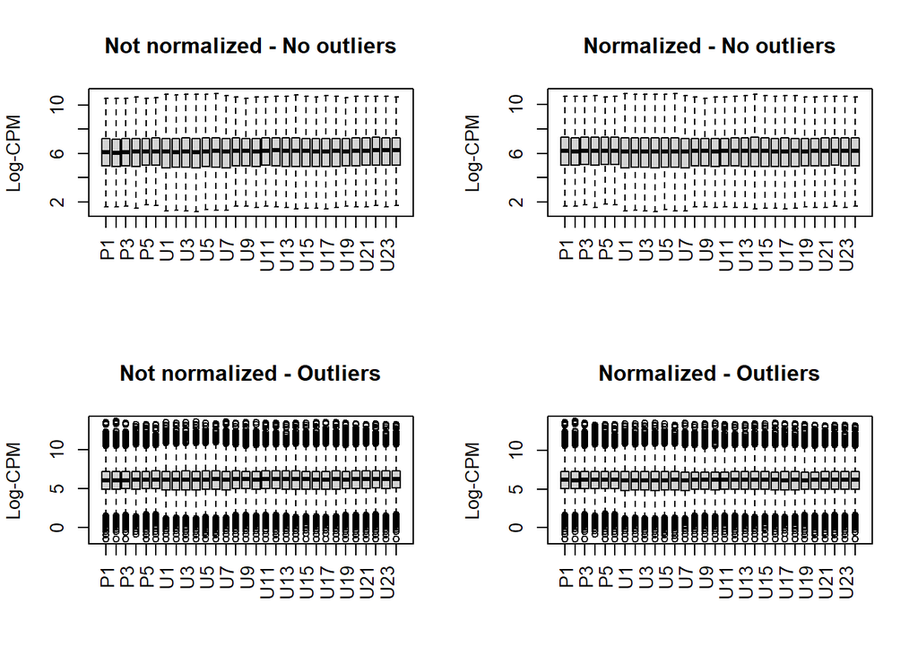

```r
#Let's check the effect
lcpm_y_Filtered <- cpm(y_Filtered, log = TRUE) #calculate lcpm of non-normalized data
lcpm_y_TMM <- cpm(y_TMM, log = TRUE) #calculate lcpm normalized data

#boxplot to check effect normalization (without outliers)
par(mfrow=c(2,2))
boxplot(lcpm_y_Filtered, las= 3, outline = FALSE, main = "Not normalized - No outliers", ylab = "Log-CPM")
boxplot(lcpm_y_TMM, las = 3, outline = FALSE, main = "Normalized - No outliers", ylab = "Log-CPM")

#boxplot to check effect normalization (with outliers)
boxplot(lcpm_y_Filtered, las= 3, outline = TRUE, main = "Not normalized - Outliers", ylab = "Log-CPM")
boxplot(lcpm_y_TMM, las = 3, outline = TRUE, main = "Normalized - Outliers", ylab = "Log-CPM")
```

### Dispersion estimation

We can analyze using pairwise contrasts, or using a generalized linear model. Here is demonstrated how to do pairwise.

8. Estimate the dispersion across all genes:

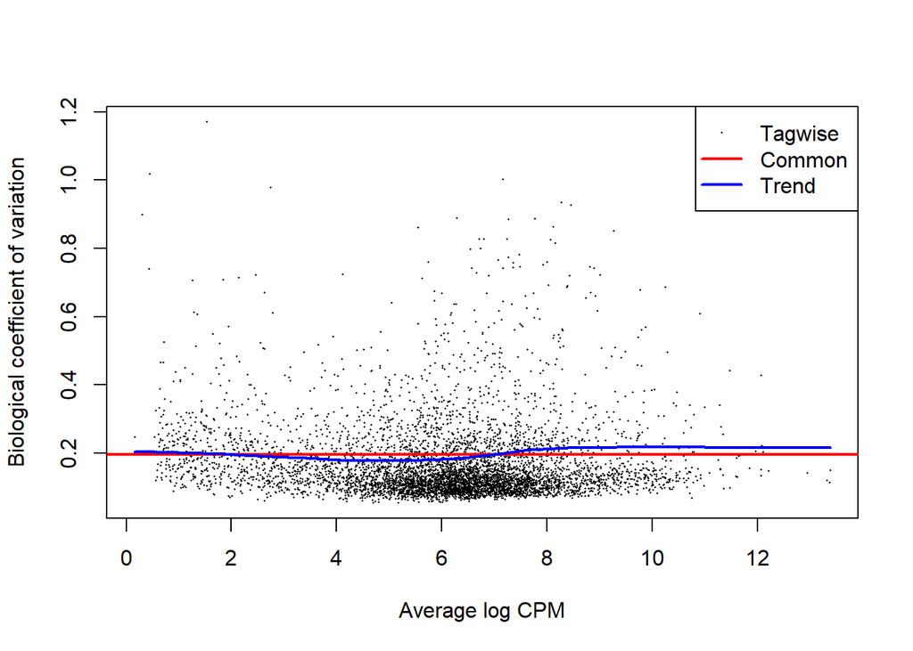

```r
#Using the grouping, we can now do an additional correction for the mean-variance correlation
y_MV <- estimateDisp(y_TMM)
#We can also view the dispersion estimates using the BCV plot:
plotBCV(y_MV)
```

The results of this plot give us an idea about the variance across all genes that are lowly expressed all the way to highly expressed. Normally, the more lowly expressed genes will have larger variation compared to the more highly expressed genes. (“Tagwise” is gene by gene dispersion, “common” is dispersion aross the whole dataset and “trend” takes groups of similarily expressed genes plot dispersion.)

### Test for differential expression

9. Now we can get lists of DE genes using the **exactTest** function:

```r
et <- exactTest(y_MV)
# This will compare 'pheromone' with 'unaffected'. Show top 20 results:
topTags(et, n=20)
```

```
## Comparison of groups:  pheromone-unaffected
##              logFC   logCPM        PValue           FDR
## YBR296C   6.052322 8.166634  0.000000e+00  0.000000e+00
## YDL222C   5.760039 6.666484  0.000000e+00  0.000000e+00
## YNL279W   4.976682 7.538630  0.000000e+00  0.000000e+00
## YGR067C   4.815722 6.233449  0.000000e+00  0.000000e+00
## YGR289C   4.781107 6.701082  0.000000e+00  0.000000e+00
## YBR299W   4.153212 5.435446  0.000000e+00  0.000000e+00
## YKL217W   3.981321 6.060395  0.000000e+00  0.000000e+00
## YOR385W   3.600483 7.092554  0.000000e+00  0.000000e+00
## YPR145C-A 3.469952 5.370367  0.000000e+00  0.000000e+00
## YAL054C   3.014197 5.899147  0.000000e+00  0.000000e+00
## YDL234C   2.984349 7.486820  0.000000e+00  0.000000e+00
## YCR007C   2.622864 4.492568  0.000000e+00  0.000000e+00
## YOR062C   2.283425 5.004804  0.000000e+00  0.000000e+00
## YGR087C   3.674388 5.621728 8.814131e-321 3.785042e-318
## YPL111W   3.202081 6.858477 2.752691e-301 1.103279e-298
## YER065C   2.699908 6.515414 4.506195e-296 1.693203e-293
## YBR169C   3.289078 6.631883 2.301287e-288 8.138433e-286
## YGR088W   5.707778 7.395972 1.019896e-284 3.406454e-282
## YLR417W   2.419677 6.647969 3.270008e-277 1.034699e-274
## YDL215C   2.166971 7.146500 2.546247e-274 7.654018e-272
```

> **Question 4**: Take a closer look at these genes (you can use the [Saccharomyces Genome Database](https://www.yeastgenome.org/) for help). Do you see anything interesting related to their functions?

> **Answer:**

The table of DE results is saved in et$table, but it does not contain the FDR-adjusted p-values. We can add this using the **p.adjust** function:

```r
res.table <- et$table
res.table$FDR <- p.adjust(res.table$PValue, 'BH')  # BH = Benjamini-Hochberg method
```

For a brief recap on why FDR adjustment is important, during multiple testing, take a look [here](https://www.explainxkcd.com/wiki/index.php/882:_Significant).

Now we can view DE genes:

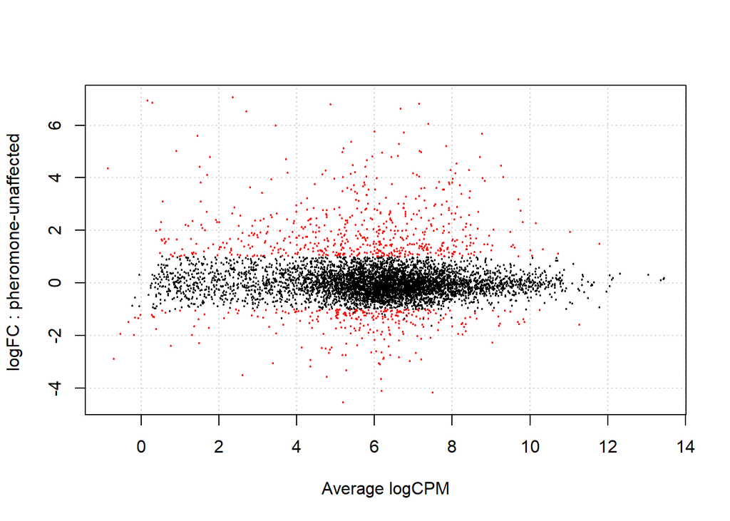

```r
# Make a smear plot, highlighting as DE those genes that have FDR < 0.01
plotSmear(y_MV, de.tags = rownames(
  res.table)[res.table$FDR < 0.01 & abs(res.table$logFC) > 1])
```

```r
# If you want to save a plot, you can easily do this by (1) specifying the pdffunction, (2) making the plot, and (3) switching off the writing of files.
pdf("data/DE_results/smearPlot.pdf")
plotSmear(y_MV, de.tags = rownames(
  res.table)[res.table$FDR < 0.01 & abs(res.table$logFC) > 1])
dev.off()
```

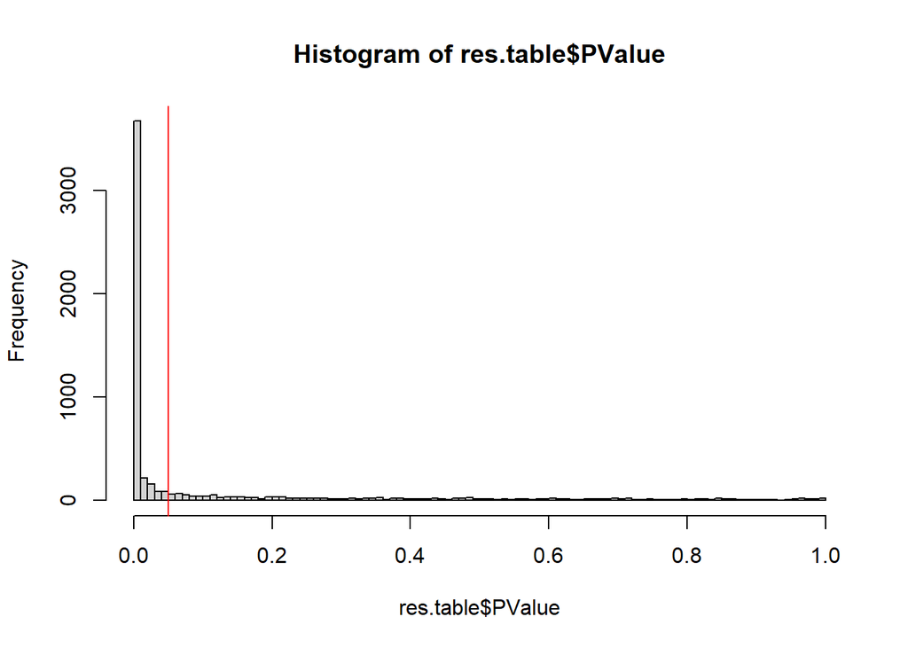

```r
# Make histogram of p-values, add vertical line at p = 0.05
hist(res.table$PValue, breaks = 100)
abline(v = 0.05, col = 'red')
```

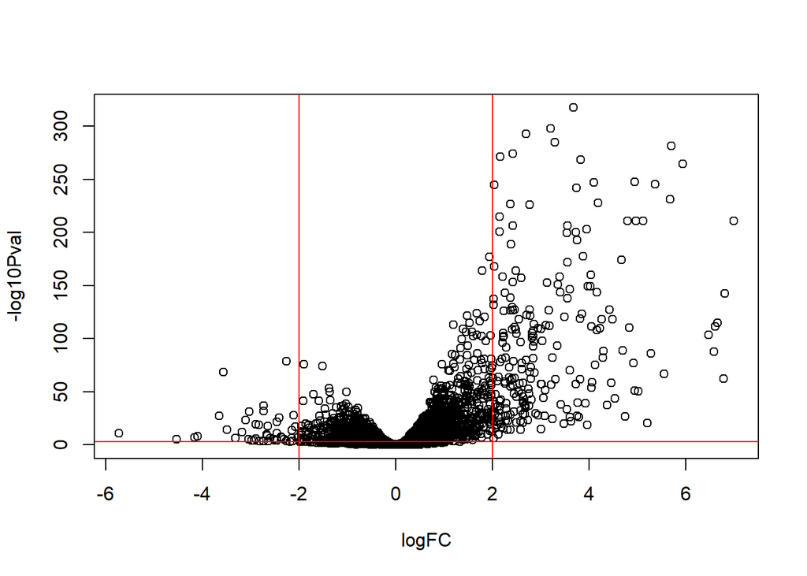

```r
# Make volcano plot
volcanoData <- cbind(res.table$logFC, -log10(res.table$FDR))
colnames(volcanoData) <- c("logFC", "-log10Pval")
plot(volcanoData)
abline(v = c(-2, 2), col = 'red')
abline(h = 3, col = 'red')
```

### Export results

10. Export the results table to a .txt file:

```r
# note: this command will overwrite the existing pre-generated DE_results_glucose.txt file
write.table(res.table, file = 'data/DE_results/DE_results_glucose.txt', quote=F, sep='\t')
```

## Data with multiple variables

In many cases, samples can be classified/grouped by more than one experimental variable/condition. For example, in a clinical trial, we may have untreated and treated subjects, as well as male and female. Often, we may want to look at differences between the different grouping types (untreated vs. treated, and male vs. female), or attempt to prevent factors associated with one variable influencing our analysis of another. For example, if we are only interested in the effect of the drug treatment, we don’t want differences in subject gender to bias the results.

Such cases can be approached using generalized linear models (GLMs). In this case, the variables deemed important by the scientist (that’s you) can be included together in a linear model, that is fit to the data, thus enabling estimation of expression changes based on those variables.

### Data setup and exploration

We avoided such a situation in the example above by separating the glucose and ethanol conditions into two separate datasets, which were analyzed individually. But what if we wanted to combine these data together?

11. Import both gene count files:

```r
# load the glucose data, and append column names with a "g"
glucose.data <- read.delim('data/gene_counts/gene_counts_glucose.txt',
                           stringsAsFactors=F, row.names=1)
colnames(glucose.data) <- paste(colnames(glucose.data), 'g', sep='')

# load the ethanol data, and append column names with a "e"
ethanol.data <- read.delim('data/gene_counts/gene_counts_ethanol.txt',
                           stringsAsFactors=F, row.names=1)
colnames(ethanol.data) <- paste(colnames(ethanol.data), 'e', sep='')
```

12. Merge the count data by gene IDs (row names):

```r
# merge datasets (by=0 indicates we merge by row names)
count.data_m <- merge(glucose.data, ethanol.data, by=0)

# set the row names as the gene IDs, and remove the "Row.names" column
row.names(count.data_m) <- count.data_m$Row.names
count.data_m <- count.data_m[,-1]

# preview our merged dataframe
head(count.data_m)
```

```
##          P1g P2g P3g P4g P5g P6g U1g U2g U3g U4g U5g U6g U7g U8g U9g U10g U11g
## 15S_rRNA   7  10  14  16  45   7 127   9   0   6   1   3  11   9  36    6    5
## 21S_rRNA  17  36  37  54 110  32 291  19  13  15  33   8  14  21  61   10   14
## HRA1       0   1   2   0   1   3   6   1   5   6   4   6   2   3   1    4    2
## ICR1      90  58  81  56  62  75  68  60  68  64  85  61  53  61  59   65   60
## LSR1     194 187 252 273 314 363 209 104 118  83 104 109  51  48  59   31   47
## NME1      35  22  27  13  14  15   9   8   9  14   6  23  11  12  16    8    6
##          U12g U13g U14g U15g U16g U17g U18g U19g U20g U21g U22g U23g U24g P1e
## 15S_rRNA    3    5    5    3    9    9   58   11    4    1    1    2    8  69
## 21S_rRNA    6   14    7    7   28   33  113   29    5    9   12    7   18 261
## HRA1        1    3    6    1    1    2    2    4    1    3    2    3    4   6
## ICR1       69   61   64   63   78   39   62  107   88  100  100   92  100  45
## LSR1       34   59   37   39   55   38   78   67   58   49   61   76   61 439
## NME1        7   13    8   11   26    9   19   13   15   11   14   13   12  17
##          P2e P3e P4e P5e P6e U1e U2e U3e U4e U5e U6e U7e U8e U9e U10e U11e U12e
## 15S_rRNA  25  61  21  10  19  18  59  69  22  20  16   4  20  16    6   17   15
## 21S_rRNA 109 209  76  54  80  77 247 180  62  79  62  35  47  28   32   61   50
## HRA1      15   7  11  18  13   5   2   2   1   2   3   3   2   0    0    2    1
## ICR1      57  56  45  52  38  75  66  80  93  61  87  74  80  87   82   96   84
## LSR1     490 475 343 415 423 108 161 171 134 103 130 146 120 115  125  119  112
## NME1      26  13  22  19  20  17  17  26  18  19  28  14  12  10   13   21   23
##          U13e U14e U15e
## 15S_rRNA   26   38  105
## 21S_rRNA   83  122  305
## HRA1        0    2    4
## ICR1      114  105   97
## LSR1      170  153  239
## NME1       20   14   10
```

13. As before, create a DGEList object from the count.data dataframe:

```r
y_m <- DGEList(counts=count.data_m)
```

Notice that this time, we did not specify the sample groups when creating our DGEList. The group is only specified at this step when dealing with a single variable (as in the example above), which is no longer the case. We will specify the sample grouping assignments in the next step.

14. Take a look at the multidimensional scaling (MDS) plot (using colors this time):

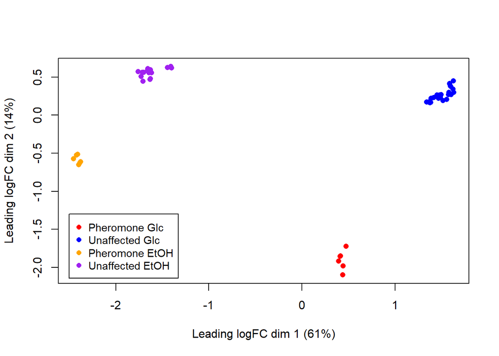

```r
plotMDS(y_m, pch=16,
        col=c(rep('red',6), rep('blue',24), rep('orange',6), rep('purple',15)))
legend(-2.5,-1.3, c('Pheromone Glc', 'Unaffected Glc', 'Pheromone EtOH', 'Unaffected EtOH'),
       col=c('red','blue','orange','purple'), pch=16, cex=0.9)
```

> **Question 5**: What do you see? Are you surprised by this result?

> **Answer:**

### Data classification

15. Generate a design matrix to classify each of our samples based on carbon source and pheromone status:

```r
# specify pheromone and carbon attribute of each sample
pheromone <- factor(startsWith(colnames(count.data_m), 'P'), labels=c('unaffected','pheromone'))
carbon <- factor(endsWith(colnames(count.data_m), 'e'), labels=c('glucose','ethanol'))

# generate design matrix
design <- model.matrix(~carbon + pheromone)
rownames(design) <- colnames(y_m)
```

> **Question 6**: Does the design matrix make sense?

> **Answer:**

### Data filtering, normalization, and dispersion

16. Filter low-count genes from the count data, this time by providing our design matrix as sample groups were not specified in the DGEList object:

```r
keep <- filterByExpr(y_m, design=design, min.count = 10)
y_m <- y_m[keep, , keep.lib.sizes=F]
```

17. Calculate the normalization factors for each sample:

```r
y_m <- calcNormFactors(y_m)
```

18. Estimate the dispersion across all genes:

```r
y_m <- estimateDisp(y_m, design)  # now further informed by design matrix
```

19. Take a look at the BCV plot:

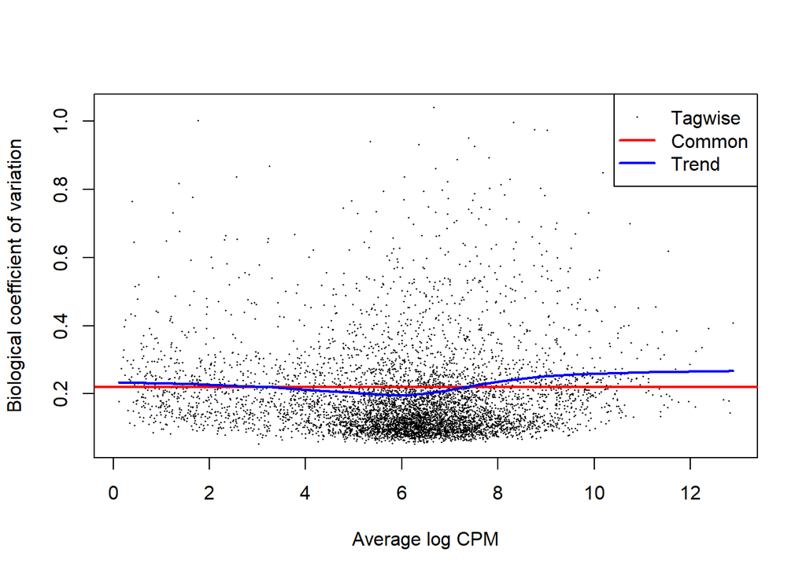

```r
plotBCV(y_m)
```

### GLM fitting and DE estimation

We are now ready to fit our GLM to the count data. To do this, we will use the glmQLFit function, which fits a **quasi-likelihood** negative binomial model to the count data.

What this means is that we are fitting each gene’s mean expression and variance to a negative binomial distribution, which has been found to sufficiently approximate the observed distribution of RNA-Seq data. However, the use of this distribution alone can still lead to an underestimation of the false-discovery rate (i.e., too many significant genes). Therefore, the “quasi-likelihood” approach includes an additional parameter when fitting the GLM that incorporates uncertainty of the modeled variances, yielding a more accurate representation (see, e.g., [S. P. Lund, et al. (2012) Stat Appl Genet Mol Biol](https://www.degruyter.com/document/doi/10.1515/1544-6115.1826/html)).

20. Fit the GLM:

```r
fit <- glmQLFit(y_m, design)
# Inspect the coefficients that are found
head(fit$coefficients)
```

```
##          (Intercept) carbonethanol pheromonepheromone
## 15S_rRNA   -12.90072     0.3919237          0.1032844
## 21S_rRNA   -12.03775     0.7045287          0.2895330
## ICR1       -11.24431    -0.2926431         -0.2829759
## LSR1       -11.29899     0.2989785          1.2029982
## NME1       -13.00480    -0.1166166          0.3089571
## RDN5-1     -12.07672     0.3207830          0.0263226
```

Alternatively, we could use the glmFit function, which uses a slightly different algorithm. You can find more details in the [edgeR User’s Guide](https://bioconductor.org/packages/release/bioc/vignettes/edgeR/inst/doc/edgeRUsersGuide.pdf). Now we want to use our fitted GLM to estimate the expression change between the pheromone-affected and pheromone-unaffected samples, while ignoring differences associated with the carbon source (glucose vs. ethanol). To do so, we will perform what is known as “blocking”, where the effect of the carbon source difference is “blocked” from our expression change estimation.

21. Perform a likelihood test to estimate gene expression changes caused by the pheromone:

```r
qlf <- glmQLFTest(fit)
 # take a look at the most affected genes
topTags(qlf, n=20)
```

```
## Coefficient:  pheromonepheromone
##               logFC   logCPM         F       PValue          FDR
## YCR007C   2.3722774 5.051306 1421.5886 7.395716e-39 4.502512e-35
## YDR070C   2.3956625 4.311373 1307.4403 6.054904e-38 1.843113e-34
## YNL193W   1.2924415 6.545082 1233.0097 2.401423e-37 4.873288e-34
## YDR006C   0.9853309 7.226652 1209.6171 3.835484e-37 5.837606e-34
## YLR267W   3.6715643 8.703413 1057.3880 1.022620e-35 1.245142e-32
## YLR417W   2.0662886 6.674454 1034.0934 1.747912e-35 1.773548e-32
## YER020W   1.3822859 7.867242  906.6019 4.220558e-34 3.670679e-31
## YML128C   3.4927845 7.594908  878.1195 9.123497e-34 6.942981e-31
## YDR046C   2.0819867 4.699518  863.7908 1.363745e-33 9.224977e-31
## YER121W   2.2053633 4.880276  859.4648 1.623313e-33 9.882729e-31
## YDR453C   2.7973055 5.292115  809.8215 6.417303e-33 3.551686e-30
## YDL215C   2.0969770 9.863197  779.1564 1.606181e-32 8.148693e-30
## YER184C   1.7821492 4.879659  753.8991 3.545299e-32 1.542378e-29
## YBR241C   1.6934594 6.559316  753.7965 3.546862e-32 1.542378e-29
## YMR165C   0.8505660 6.774471  733.3412 6.824934e-32 2.770013e-29
## YNR034W-A 4.3150750 6.446099  674.4867 5.044891e-31 1.919581e-28
## YGR154C   1.4930520 4.709439  646.6476 1.358993e-30 4.866792e-28
## YOR005C   1.0447717 6.044843  643.4829 1.518017e-30 5.134270e-28
## YDL222C   4.7714681 6.442971  632.8453 2.264974e-30 7.211585e-28
## YJL206C   1.7434659 6.157293  630.9730 2.414287e-30 7.211585e-28
```

Notice we didn’t specify which comparison we wanted to perform (pheromone affected vs. unaffected, or glucose vs. ethanol). This is because by default the **glmQLFTest** function will test the last (3rd) coefficient in the model (**pheromone** in our case). If we instead wanted to look at gene expression changes between glucose and ethanol samples, we would specify this using the **coef** argument: e.g., **qlf <- glmQLFTest(fit, coef=2)**, because the 2nd coefficient relates to carbon source (the 1st coefficient is simply the intercept, or baseline).

22. Add the FDR values to the results table:

```r
res.table_m <- qlf$table
res.table_m$FDR <- p.adjust(res.table_m$PValue, 'BH')  # BH = Benjamini-Hochberg method
```

23. Now we can view DE genes:

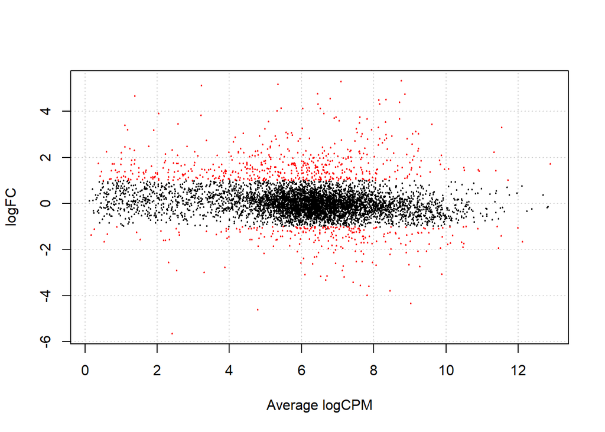

```r
# Make a smear plot, highlighting as DE those genes that have FDR < 0.01
plotSmear(qlf, de.tags = rownames(
  res.table_m)[res.table_m$FDR < 0.01 & abs(res.table_m$logFC) > 1])
```

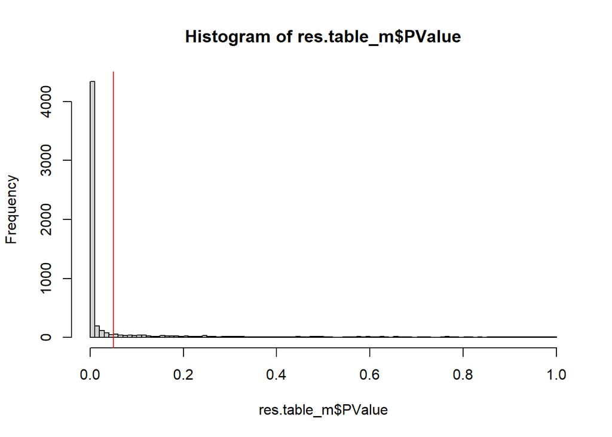

```r
# Make histogram of p-values, add vertical line at p = 0.05
hist(res.table_m$PValue, breaks = 100)
abline(v = 0.05, col = 'red')
```

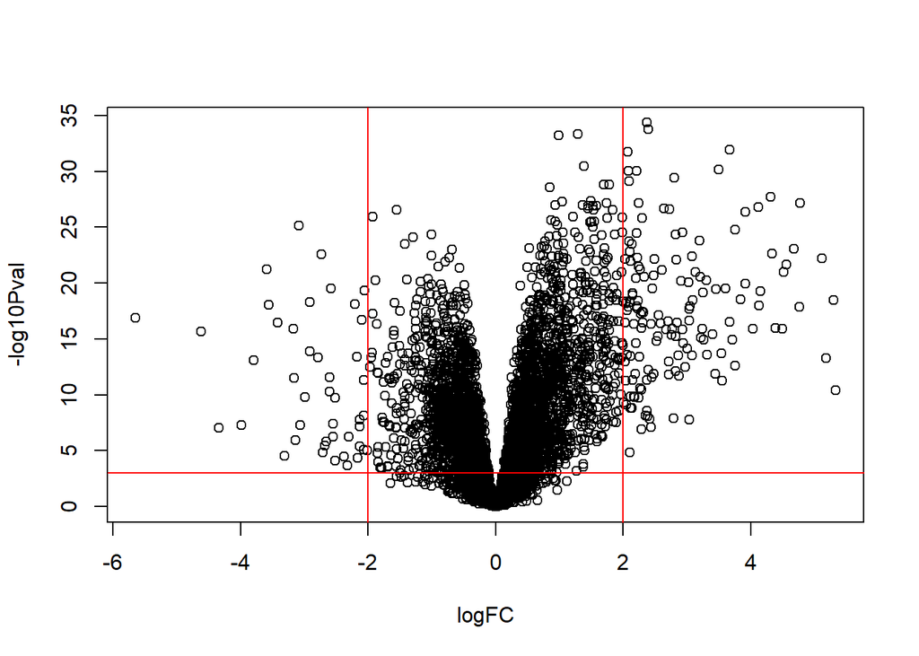

```r
# Make volcano plot
volcanoData_m <- cbind(res.table_m$logFC, -log10(res.table_m$FDR))
colnames(volcanoData_m) <- c("logFC", "-log10Pval")
plot(volcanoData_m)
abline(v = c(-2, 2), col = 'red')
abline(h = 3, col = 'red')
```

> **Question 7**: How do these results compare to those in the first analysis?

> **Answer:**

### Export

24. Export the results table to a .txt file:

```r
write.table(res.table_m, file = 'data/DE_results/DE_results_merged.txt', quote=F, sep='\t')
```

## Session info

This page was generated using the following R session:

```
##                _
## platform       x86_64-w64-mingw32
## arch           x86_64
## os             mingw32
## crt            ucrt
## system         x86_64, mingw32
## status
## major          4
## minor          5.3
## year           2026
## month          03
## day            11
## svn rev        89597
## language       R
## version.string R version 4.5.3 (2026-03-11 ucrt)
## nickname       Reassured Reassurer
```